# neotoma: A Programmatic Interface to the Neotoma Paleoecological Database

## Abstract:

Paleoecological data is an integral part of ecological analysis. It provides an opportunity to study interactions between ecological communities and abiotic environments at time scales that cannot be observed through modern field studies. Paleoecological analysis allows us to observe changes in ecological processes that operate at centennial and millennial scales, or processes that occur infrequently, such as megadroughts, hurricanes, rapid climatic change and volcanic eruptions. Paleoecological inference also can allow us to understand ecological processes in the absence of widespread antrhopogenic influence.

To assist with the use of the `neotoma` package we provide examples of key functions using examples from the published literature, for both plant and mammal taxa.

## Introduction

Paleoecological data are used to understand patterns and drivers of biogeographical, climatic and evolutionary change at multiple spatial and temporal scales. Paleoecoinformatics [@brewer2012paleo; @uhen2013card] is increasingly providing tools to researchers across disciplines to access and use large datasets spanning thousands of years. These datasets may be used to provide better insight into patterns of biomass burning (Blarquez et al, 2013; Power et al.), regional vegetation change [@blois2013modeling; @blarquez2014disentangling] or changing sedimentation rates through time [@goring2012depo]. The increasing interest in uniting ecological and paleoecological data to understand modern ecological patterns and responses to climate change [@fritz2013diversity; @behrensmeyer2012building; @dietl2011conservation] means that efforts to unite these two, seemingly independedent data-streams will rely, in part, on more robust tools to access and synthesize paleoecological data.

The Neotoma Paleoecological Database is the result of longstanding collaboration between the European Pollen Database and the North American Pollen Database [@grimm2013databases]. The database framework was generalized from pollen data to accomodate other macro- and microfossil data and other geochemistry information including loss-on-ignition and isotope records. Constituent databases include the European, Indo-Pacific, Latin American, North American Pollen Database, FAUNMAP (Pliocene to Quaternary mammal fossils in the continental United States), the North American Non-Marine Ostrocode Database, and the Diatom Paleolimnology Data Cooperative. Work is underway to include the North American Fossil Beetle Database, testate amoeba records, the North American Plant Macrofossil Database and the Digital Archaeological Record, thus further expanding the data that can be accomodated by Neotoma. Through the use of data stewards - domain-specific experts who can check for inaccuracies, upload and manage data records - Neotoma can support high quality assurance for each of the constituent data types, and receive feedback from research communities involved with each specific data type [@grimm2013databases].

From the paleoecological database Neotoma has also developed Application Programming Interfaces, that allow users to query the database through the internet using properly formed URLs. For example, the URL: http://api.neotomadb.org/v1/apps/geochronologies/?datasetid=8 will return all geochronological data for a single record associated with the datasetid provided.

The statistical software R [@RCoreTeam2014] is commonly used for analysis of paleoecological data and several packages in R exist for analysis including `analogue` [@analogue2013; @analogue2007] and `rioja` [@rioja2013] for paleoenvironmental reconstruction, `Bchron` for radiocarbon dating and age-depth modeling [@bchron2014] and `paleofire` to access and analyse charcoal data [@paleofire2014]. Notwithstanding these packages, the use of extensive paleoecological resources within R has traditionally relied on *ad hoc* methods of obtaining and importing data. This has meant reliance on datasets such as those from the NOAA Paleoclimate Repository or the North American Modern Pollen Database, and on the distribution of individual datasets from author to analyst.

With an increasing push to provide paleoecological publications that include numerically reproducible results (e.g., @goring2012depo; @gill2013linking; @goring2013pollen) it is important to provide tools that allow analysts to directly access dynamic datasets, and to provide tools to support reproducible workflows. The rOpenSci project has provided a number of tools that can directly interact with application programmatic interfaces (APIs) to access data from a number of databases including rfishbase (FishBase: [@boettiger2012rfishbase] and taxize (Encyclopedia of Life, iPlant/Taxosaurus and others: [@chamberlain2013taxize] among others.

To illustrate use cases for the `neotoma` package we present examples drawn from the paleoecological literature to illustrate how `neotoma` provides the tools to perform research that is critical to understanding paleoecological change in the Pleistocene in an open and reproducible manner.

## The `neotoma` package

Here we describe `neotoma`, an R package that acts as an interface between a large dynamic database (the Neotoma Paleoecological Database: http://neotomadb.org) and statistical tools in R. `neotoma` uses an API to send data requests to Neotoma, and then forms data objects that can interact with existing packages such as `analogue` [@analogue2013] and `rioja` [@rioja2013], that are used for environmental reconstruction, manipulation and presentation of paleoecological data. The `neotoma` package also includes tools to standardize pollen data across sample sites using a set of commonly accepted pollen taxa.

Data in the neotoma package is represented in three main classes. (1) a `site` is the most basic form of spatial information, it is a representation of all data points, as a special class of `data.frame`. A `site` contains site names, locations and, when supplied, site descriptions, along with a unique `siteID`. Individual sites can be associated with one or more `dataset`s. A `dataset` is a special type of `list` that includes a `site` class for each dataset, but also includes information about the particular dataset, including the data type, the principle investigator, the submission date to Neotoma and the date that the information was accessed from Neotoma using the R package. The `dataset` also includes a unique `dataset.id` that can be used to access the full `download`. A `download` contains both `site` and `dataset` information, but it also contains the full data object for the dataset it references, whether it is pollen, ostrocode, mammal or other data.

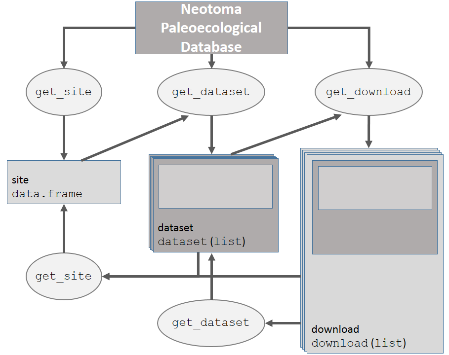

**Figure 1**. *How the main data objects relate to one another in the `neotoma` package, and the helper functions used to move from one data type to another.*

## Examples

Macdonald and Cwynar [-@macdonald1991post] used pollen percentage data for *Pinus* to map the northward migration of lodgepole pine (*Pinus contorta* var *latifolia*) following glaciation. In their study a cutoff of 15% *Pinus* pollen is associated with presence at pollen sample sites. Recent work by Strong and Hills [@strong2013holocene] has remapped the migration front using a lower pollen proportion (5%) and more sites. Here, we attempt to replicate the analysis as an example both of the strengths of the package and limitations of paleoinformatic approaches.

To begin we must define a spatial bounding box and a set of taxa of interest. Strong and Hills [-@strong2013holocene] use a region approximately bounded by 54<sup>oN</sup> to the south and 65<sup>oN</sup> to the North, and from 110<sup>o<sup>W</sup></sup> to 130<sup>o<sup>W.</sup></sup> The function `get_site()` is used to find all sites within a bounding box:

```r
library("neotoma")
library("analogue")  # why don't we use our ggplot pollen diagram code?
library("ggmap")
library("ggplot2")
library("reshape2")
library("plyr")
library("Bchron")  # in turn requires rgl, ks, hdcde ... get rid of this one?
library("gridExtra")  # use multiplot function instead?
library("knitr")

all.sites <- get_site(loc = c(-140, 45, -110, 65))
```

```
#> The API call was successful, you have returned  442 records.
```

`get_site()` returns an object of class `site` and `data.frame`, with the columns `siteid`, `sitename`, `lat`, `long`, `elev`, `description`, `long_acc`, and `lat_acc`. Each row represents a unique site, and provides enough descriptive data to plot sites and understand the spatial extent of a site. Using the class assingment `site` allows objects returned by `get_site()` to be easily recognized by other functions, so that site information can easily be used to obtain datasets or whole data downloads.

Our code above returns a total of 442 sites. Sites, conceptually, are containers for datasets. Generally it's better to search for a neotoma dataset. The `neotoma` package allows you to use almost all of the same search terms in `get_dataset()` as in `get_site()`, and returns a more complete description of the datasets available. But, when you search for a dataset you can also limit the type of dataset, either by looking for specific taxa, or by describing the dataset type (*e.g.*, `pollen` or `mammal`). In the next example we will look for all taxa beginning with *Pinus* in a pollen dataset within a bounding box corresponding to Washington State in the USA and British Columbia and the Yukon Territory in Canada. We use the `*` wildcard to indicate any and all taxa with *Pinus* in their name:

```r
all.datasets <- get_dataset(loc = c(-140, 45, -110, 65), datasettype = "pollen",
    taxonname = "Pinus*")
```

A `dataset` is an object with classes `list` and `dataset`. The dataset has site information, but it also has information about the specific dataset, so the site data is nested within the dataset. The use of a specific `dataset` class allows us to easily move between `get_dataset()`, `get_site()` and `get_download()` by using S3 methods in R.

The API tells us we now have 68 datasets from the original 442 sites. Many of the samples that are not included are pollen surface samples, or vertebrate fauna, meaning pollen core data comprises much less than half of the records. Regardless, we now know that there is pollen core data from 68 sites and we can plot those sites over our original 442.

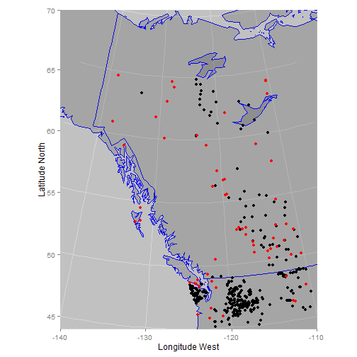

```r
map <- map_data("world")
ggplot(data = data.frame(map), aes(long, lat)) + geom_polygon(aes(group = group),
    color = "blue", alpha = 0.2) + geom_point(data = all.sites, aes(x = long,
    y = lat)) + geom_point(data = get_site(all.datasets), aes(x = long, y = lat),
    color = 2) + xlab("Longitude West") + ylab("Latitude North") + coord_map(projection = "albers",
    lat0 = 40, lat1 = 65, xlim = c(-140, -110), ylim = c(45, 70))
```

So we see that there are a number of sites in the interior of British Columbia that have no core pollen. For many of these cores pollen records exist. This is an obvious limitation of the use of large datasets. While many dataset have been entered into Neotoma, a large number have yet to make their way into the repository. An advantage of the API-based analysis however is that analysis using Neotoma can be updated continuously as new sites are added.

Let's get the data for each of the cores we have. Because we have assigned the `dataset` class to the output of `get_dataset()` it means that the function `get_download()` can immediately recognize the `dataset` object and extract the dataset ID from it to use in obtaining full records from the API:

```r
# This step may be time consuming when you run it, particularly if you have
# a slow internet connection.

if (!file.exists("all.downloads.Rdata")) {
    all.downloads <- get_download(all.datasets, verbose = FALSE)
    save(all.downloads, file = "all.downloads.Rdata")
} else {
    load(file = "all.downloads.Rdata")
}
```

`get_download()` returns an object of classes `download` and `list`, with a length equal to the number of sites returned. In most cases `get_download()` will return a message for an individual core as it is running, that can be turned off using the flag `verbose = FALSE`.

Both the `get_download()` and `get_dataset()` functions also record the time at which the API was accessed. Because of the large size of most `download`s there is a special print function that limits output size, however, the objects remain `list`s and can be manipulated as such in R.

A single `download` object is a `list` and `download` with six components:

```r
names(all.downloads[[1]])
```

```
#> [1] "metadata"     "sample.meta"  "taxon.list"   "counts"
#> [5] "lab.data"     "chronologies"
```

The `metadata` component is equivalent to a `dataset` returned by `get_dataset()`. The `sample.meta` component is where the core depth and age information is stored. The actual chronologies are stored in `chronologies`. If a core has a single age model then `chronologies` has a length of one. Some cores have multiple chronologies and these are added to the list. The default chronology is always represented in `sample.meta`, and is always the first `chronology`. If you choose to build your own chronology using `Bacon` [@blaauw2011flexible] or another method you can obtain the chronological controls for the core using `get_chroncontrol()` and the chronology ID in either `sample.meta` or any one of the `chronologies` objects. While the chronological controls used to build a chronology may vary across chronologies for a single site, the default model contains the most accurate chronological control data.

The `taxon.list` component is a critical part of the `download` object. It lists the taxa found in the core, as well as any laboratory data, along with the units of measurement and taxonomic grouping. This is important information for determining which taxa make it into pollen percentages. The `counts` are the actual count or percentage data recorded for the core. The `lab.data` component contains information about any spike used to determine concentrations, sample quantities and, in some cases, charcoal counts.